# Tugas MPDW Praktikum

M.Taqy Abiyu Dzakwan

2025-08-29

# Library

```r
library("forecast")
```

```r
library("graphics")
library("TTR")
library("TSA")
library(ggplot2)
library(rio)
```

# Persiapan data

```r
telur <- read.csv("D:/TUGAS IPB/Semester 5/mpdw/Pertemuan 1/Data/Telur Ayam Ras.csv")
head(telur)
```

```
##         Date Jawa.Barat
## 1 2022-07-14      27680
## 2 2022-07-15      27920
## 3 2022-07-16      27960
## 4 2022-07-17      27890
## 5 2022-07-18      27950
## 6 2022-07-19      28260
```

```r
str(telur)
```

```
## 'data.frame':    636 obs. of  2 variables:
##  $ Date      : chr  "2022-07-14" "2022-07-15" "2022-07-16" "2022-07-17" ...
##  $ Jawa.Barat: int  27680 27920 27960 27890 27950 28260 28150 28100 28080 28020 ...
```

```r
dim(telur)
```

```
## [1] 636   2
```

```r
telur.sub <- telur[320:479, ]
telur.sub$Date <- as.Date(telur.sub$Date)
telur.ts <- ts(telur.sub$Jawa.Barat, frequency = 1)
```

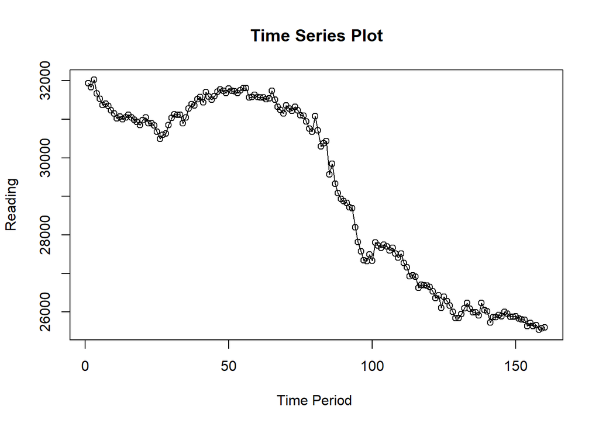

```r
ts.plot(telur.ts, xlab="Time Period ", ylab="Reading",
        main = "Time Series Plot")
points(telur.ts)
```

# Data split

```r
n <- nrow(telur.sub)
n_train <- floor(0.8 * n)

training_ma <- telur.sub[1:n_train, ]
testing_ma  <- telur.sub[(n_train+1):n, ]

train_ma.ts <- ts(training_ma$Jawa.Barat, frequency = 1)
test_ma.ts  <- ts(testing_ma$Jawa.Barat,start= length(train_ma.ts)+1, frequency = 1)
```

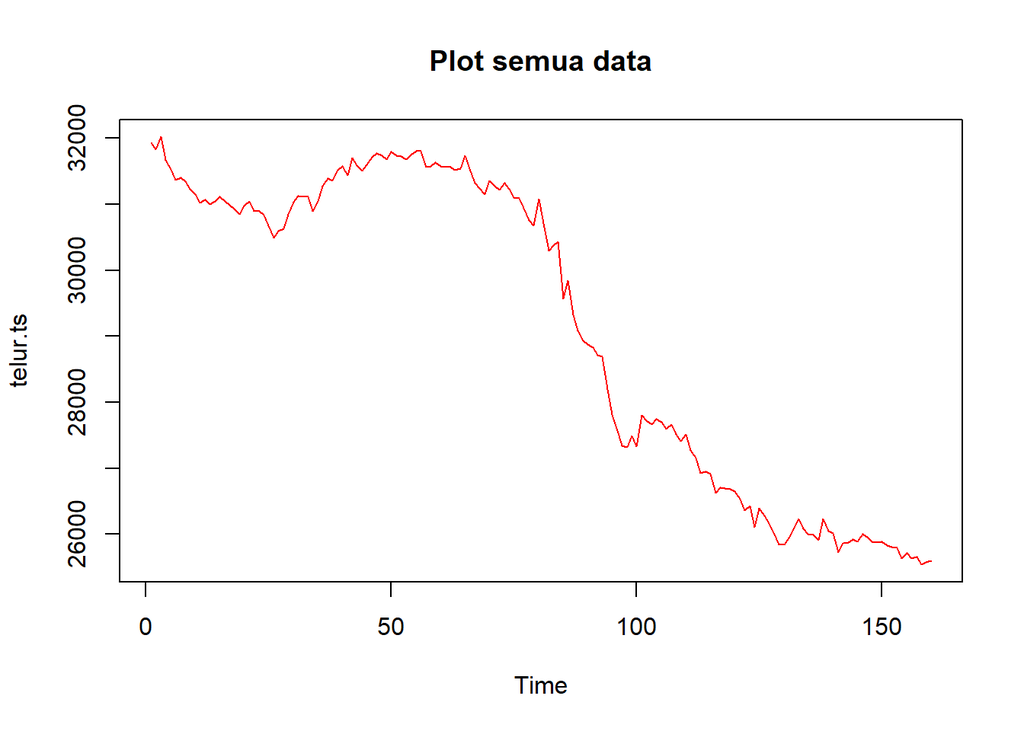

```r
plot(telur.ts, col="red", main="Plot semua data")
```

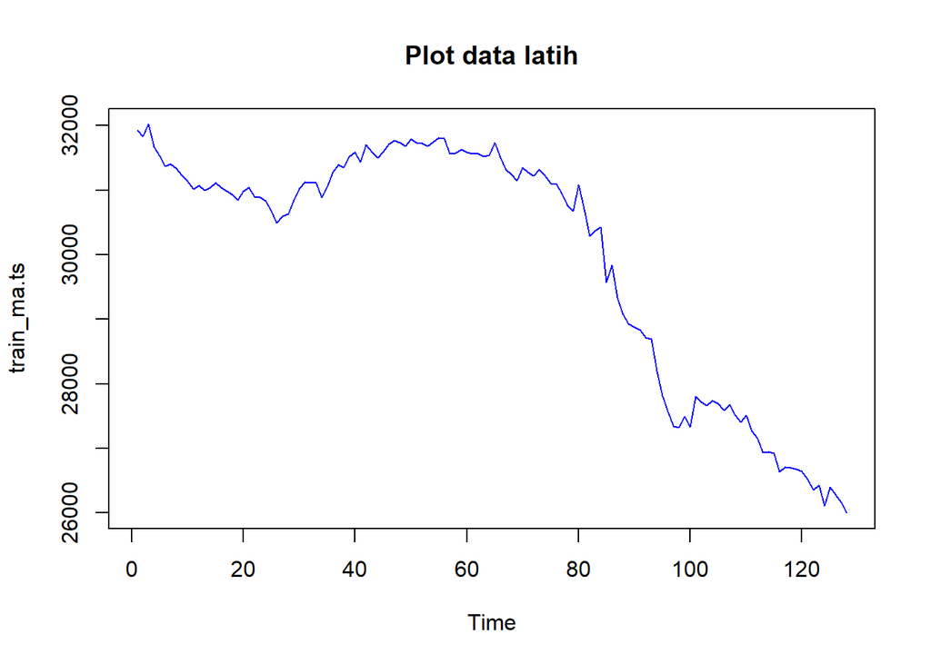

```r
plot(train_ma.ts, col="blue", main="Plot data latih")
```

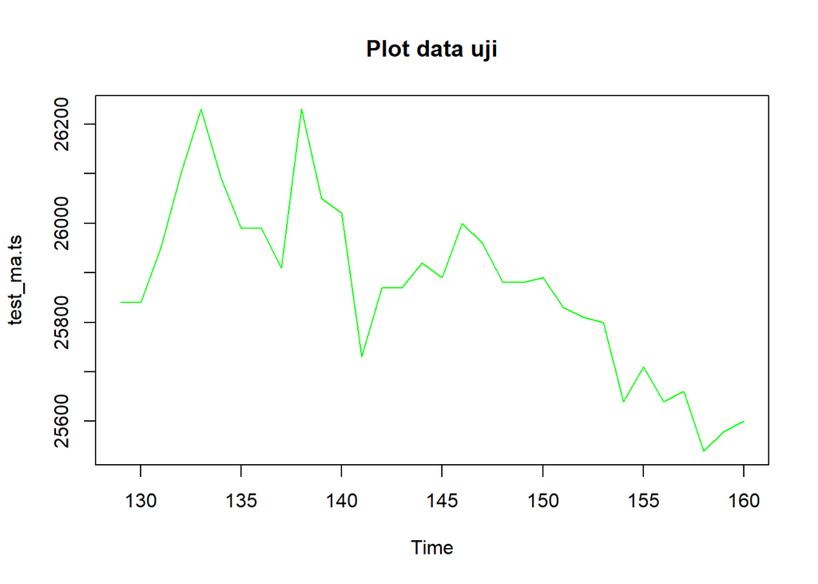

```r
plot(test_ma.ts, col="green", main="Plot data uji")
```

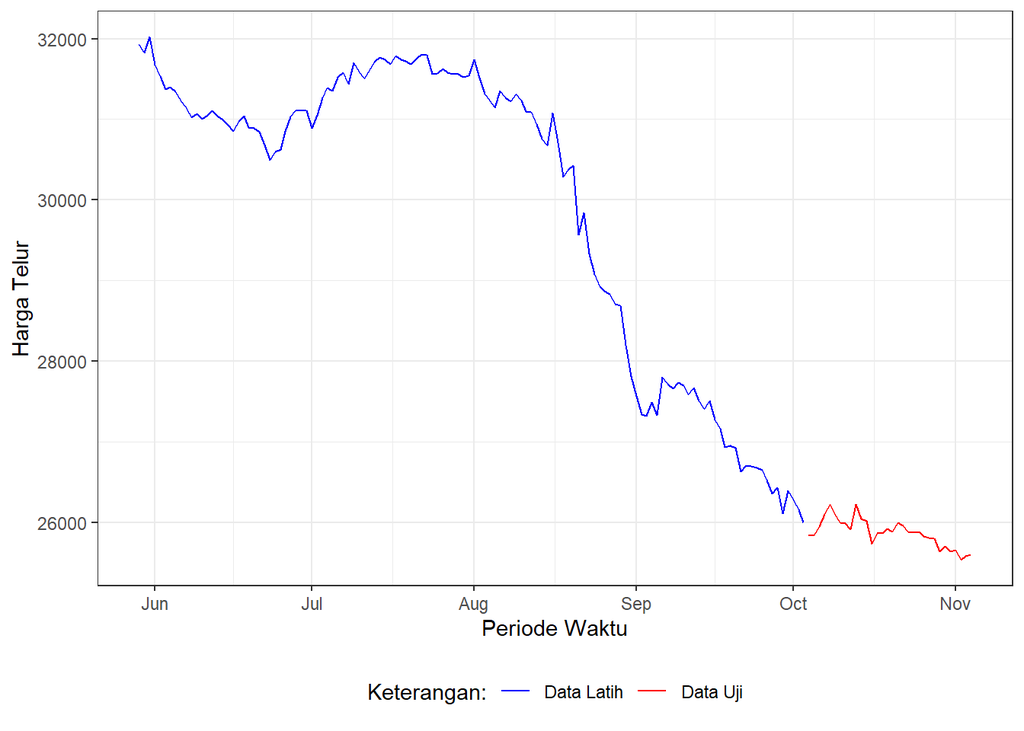

```r
ggplot() +
  geom_line(data = training_ma, aes(x = Date, y = Jawa.Barat, col = "Data Latih")) +
  geom_line(data = testing_ma, aes(x = Date, y = Jawa.Barat, col = "Data Uji")) +
  labs(x = "Periode Waktu", y = "Harga Telur", color = "Legend") +
   scale_colour_manual(name="Keterangan:", breaks = c("Data Latih", "Data Uji"),
                      values = c("blue", "red")) +
  theme_bw() + theme(legend.position = "bottom",
                     plot.caption = element_text(hjust=0.5, size=12))
```

# Single Moving Average (SMA)

```r
data.sma<-SMA(train_ma.ts, n=7) #PAKAI 7 KARENA DATANYA PERHARI
data.sma
```

```
## Time Series:
## Start = 1
## End = 128
## Frequency = 1
##   [1]       NA       NA       NA       NA       NA       NA 31678.57 31594.29
##   [9] 31508.57 31384.29 31291.43 31225.71 31172.86 31121.43 31088.57 31061.43
##  [17] 31038.57 31025.71 30994.29 30991.43 30991.43 30961.43 30940.00 30918.57
##  [25] 30882.86 30831.43 30777.14 30718.57 30711.43 30731.43 30771.43 30832.86
##  [33] 30921.43 30962.86 31022.86 31082.86 31134.29 31167.14 31225.71 31292.86
##  [41] 31371.43 31464.29 31510.00 31525.71 31561.43 31588.57 31615.71 31658.57
##  [49] 31655.71 31684.29 31718.57 31735.71 31731.43 31728.57 31738.57 31755.71
##  [57] 31722.86 31698.57 31685.71 31671.43 31644.29 31608.57 31568.57 31565.71
##  [65] 31590.00 31572.86 31535.71 31490.00 31431.43 31407.14 31368.57 31294.29
##  [73] 31267.14 31254.29 31234.29 31225.71 31167.14 31094.29 31015.71 30981.43
##  [81] 30907.14 30791.43 30688.57 30615.71 30445.71 30327.14 30077.14 29844.29
##  [89] 29650.00 29435.71 29207.14 29084.29 28920.00 28758.57 28577.14 28382.86
##  [97] 28164.29 27948.57 27774.29 27580.00 27522.86 27510.00 27522.86 27580.00
## [105] 27634.29 27648.57 27697.14 27655.71 27611.43 27590.00 27522.86 27445.71
## [113] 27351.43 27248.57 27164.29 27052.86 26938.57 26857.14 26788.57 26748.57
## [121] 26688.57 26608.57 26580.00 26494.29 26451.43 26394.29 26324.29 26248.57
```

```r
data.ramal<-c(NA,data.sma)
data.ramal
```

```
##   [1]       NA       NA       NA       NA       NA       NA       NA 31678.57
##   [9] 31594.29 31508.57 31384.29 31291.43 31225.71 31172.86 31121.43 31088.57
##  [17] 31061.43 31038.57 31025.71 30994.29 30991.43 30991.43 30961.43 30940.00
##  [25] 30918.57 30882.86 30831.43 30777.14 30718.57 30711.43 30731.43 30771.43
##  [33] 30832.86 30921.43 30962.86 31022.86 31082.86 31134.29 31167.14 31225.71
##  [41] 31292.86 31371.43 31464.29 31510.00 31525.71 31561.43 31588.57 31615.71
##  [49] 31658.57 31655.71 31684.29 31718.57 31735.71 31731.43 31728.57 31738.57
##  [57] 31755.71 31722.86 31698.57 31685.71 31671.43 31644.29 31608.57 31568.57
##  [65] 31565.71 31590.00 31572.86 31535.71 31490.00 31431.43 31407.14 31368.57
##  [73] 31294.29 31267.14 31254.29 31234.29 31225.71 31167.14 31094.29 31015.71
##  [81] 30981.43 30907.14 30791.43 30688.57 30615.71 30445.71 30327.14 30077.14
##  [89] 29844.29 29650.00 29435.71 29207.14 29084.29 28920.00 28758.57 28577.14
##  [97] 28382.86 28164.29 27948.57 27774.29 27580.00 27522.86 27510.00 27522.86
## [105] 27580.00 27634.29 27648.57 27697.14 27655.71 27611.43 27590.00 27522.86
## [113] 27445.71 27351.43 27248.57 27164.29 27052.86 26938.57 26857.14 26788.57
## [121] 26748.57 26688.57 26608.57 26580.00 26494.29 26451.43 26394.29 26324.29
## [129] 26248.57
```

Selanjutnya dilakukan peramalan sebanyak 32 periode sesuai dengan jumlah data uji. Pada metode SMA, seluruh hasil peramalan untuk 32 periode ke depan akan memiliki nilai yang sama dengan hasil ramalan satu periode ke depan.

```r
n_aktual <- length(telur.ts)
n_pemulusan <- length(data.sma)
n_ramal <- length(data.ramal)

data.gab <- cbind(
  aktual    = c(telur.ts),
  pemulusan = c(data.sma, rep(NA, n_aktual - n_pemulusan)),
  ramalan   = c(data.ramal, rep(data.ramal[n_ramal], n_aktual - n_ramal))
)

data.gab
```

```
##        aktual pemulusan  ramalan
##   [1,]  31930        NA       NA
##   [2,]  31830        NA       NA
##   [3,]  32020        NA       NA
##   [4,]  31670        NA       NA
##   [5,]  31530        NA       NA
##   [6,]  31370        NA       NA
##   [7,]  31400  31678.57       NA
##   [8,]  31340  31594.29 31678.57
##   [9,]  31230  31508.57 31594.29
##  [10,]  31150  31384.29 31508.57
##  [11,]  31020  31291.43 31384.29
##  [12,]  31070  31225.71 31291.43
##  [13,]  31000  31172.86 31225.71
##  [14,]  31040  31121.43 31172.86
```

[output cut: 146 more lines]

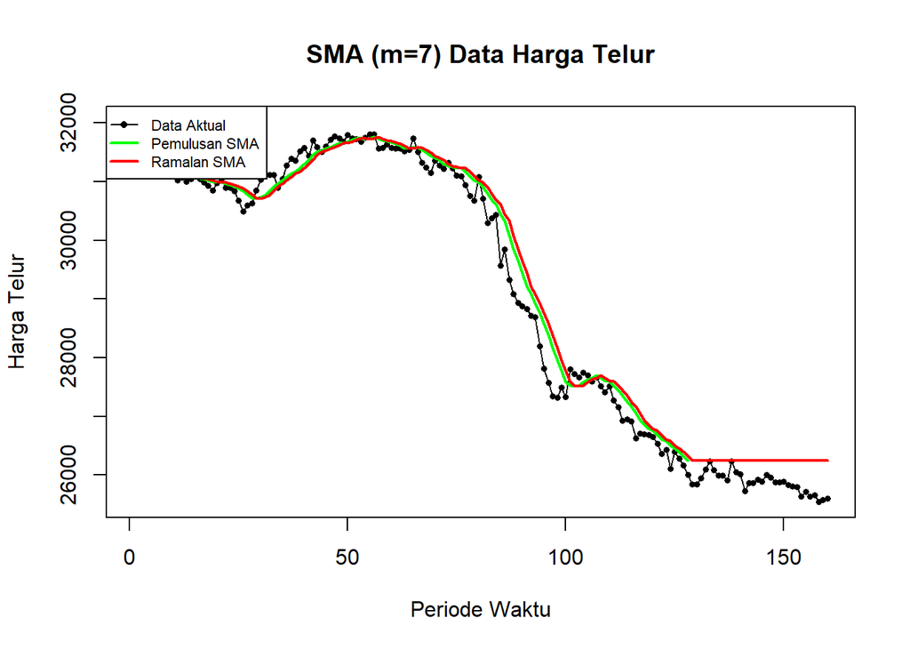

```r
# Plot aktual
ts.plot(telur.ts,
        xlab="Periode Waktu",
        ylab="Harga Telur",
        main="SMA (m=7) Data Harga Telur",
        col="black", lwd=1)
points(telur.ts, col="black", pch=16, cex=0.6)
lines(data.gab[,2], col="green", lwd=2)
lines(data.gab[,3], col="red", lwd=2)

legend("topleft",
       legend=c("Data Aktual","Pemulusan SMA","Ramalan SMA"),
       col=c("black","green","red"),
       lty=c(1,1,1),
       lwd=c(1,2,2),
       pch=c(16, NA, NA),
       cex=0.7)
```

Selanjutnya perhitungan akurasi dilakukan dengan ukuran akurasi Sum Squares Error (SSE), Mean Square Error (MSE) dan Mean Absolute Percentage Error (MAPE). Perhitungan akurasi dilakukan baik pada data latih maupun pada data uji.

```r
### Evaluasi Akurasi SMA ###

# Error data latih
error_train.sma <- train_ma.ts - data.ramal[1:length(train_ma.ts)]

SSE_train.sma <- sum(error_train.sma^2, na.rm=TRUE)
MSE_train.sma <- mean(error_train.sma^2, na.rm=TRUE)
MAPE_train.sma <- mean(abs(error_train.sma/train_ma.ts)*100, na.rm=TRUE)

akurasi_train.sma <- matrix(c(SSE_train.sma, MSE_train.sma, MAPE_train.sma),
                            ncol=1, byrow=TRUE)
row.names(akurasi_train.sma) <- c("SSE", "MSE", "MAPE")
colnames(akurasi_train.sma) <- c("Akurasi Train (m=7)")
akurasi_train.sma
```

```
##      Akurasi Train (m=7)
## SSE         1.627116e+07
## MSE         1.344724e+05
## MAPE        9.372629e-01
```

Dalam hal ini, nilai MAPE data latih pada metode pemulusan SMA (m=7) adalah sekitar 0.94%, yang berarti metode ini memiliki tingkat akurasi sangat baik karena berada di bawah 10%. Selanjutnya dilakukan perhitungan nilai MAPE data uji pada metode pemulusan SMA untuk melihat kinerja model pada data yang belum digunakan saat pelatihan.

```r
# Error data uji
error_test.sma <- test_ma.ts - data.gab[(length(train_ma.ts)+1):length(telur.ts), 3]

SSE_test.sma <- sum(error_test.sma^2, na.rm=TRUE)
MSE_test.sma <- mean(error_test.sma^2, na.rm=TRUE)
MAPE_test.sma <- mean(abs(error_test.sma/test_ma.ts)*100, na.rm=TRUE)

akurasi_test.sma <- matrix(c(SSE_test.sma, MSE_test.sma, MAPE_test.sma),
                           ncol=1, byrow=TRUE)
row.names(akurasi_test.sma) <- c("SSE", "MSE", "MAPE")
colnames(akurasi_test.sma) <- c("Akurasi Test (m=7)")
akurasi_test.sma
```

```
##      Akurasi Test (m=7)
## SSE        5.464008e+06
## MSE        1.707503e+05
## MAPE       1.455621e+00
```

Perhitungan akurasi menggunakan data uji menghasilkan nilai MAPE sebesar 1.46%. Karena nilai MAPE masih di bawah 10%, maka metode pemulusan SMA (m=7) dapat dikategorikan memiliki tingkat akurasi sangat baik dalam meramalkan data uji.

# Double Moving Average

```r
data.dma <- SMA(data.sma, n = 7)

# Langkah 3: Hitung komponen At dan Bt
At <- 2*data.sma - data.dma
Bt <- (2/(7-1)) * (data.sma - data.dma)

# Langkah 4: Hitung ramalan in-sample (At + Bt)
ramalan_dma <- At + Bt
ramalan_dma <- c(NA, ramalan_dma)   # geser 1 step biar sejajar

n_train <- length(train_ma.ts)
n_test  <- length(test_ma.ts)

# --- Ramalan out-sample sesuai panjang test ---
t <- 1:n_test
f <- sapply(t, function(i) At[length(At)] + Bt[length(Bt)]*i)

# --- Panjang data aktual ---
n <- length(telur.ts)

# --- Fungsi untuk padding ---
pad <- function(x, n) c(x, rep(NA, n - length(x)))

# --- Gabungan ramalan in-sample + out-sample ---
ramalan_all <- c(ramalan_dma, f)
ramalan_all <- ramalan_all[1:n]   # pastikan sama panjang dengan data aktual

# --- Buat data frame gabungan ---
data.gab2 <- data.frame(
  aktual     = as.numeric(telur.ts),
  pemulusan1 = pad(data.sma, n),
  pemulusan2 = pad(data.dma, n),
  At         = pad(At, n),
  Bt         = pad(Bt, n),
  ramalan    = ramalan_all
)

data.gab2
```

```
##     aktual pemulusan1 pemulusan2       At          Bt  ramalan
## 1    31930         NA         NA       NA          NA       NA
## 2    31830         NA         NA       NA          NA       NA
## 3    32020         NA         NA       NA          NA       NA
## 4    31670         NA         NA       NA          NA       NA
## 5    31530         NA         NA       NA          NA       NA
## 6    31370         NA         NA       NA          NA       NA
## 7    31400   31678.57         NA       NA          NA       NA
## 8    31340   31594.29         NA       NA          NA       NA
## 9    31230   31508.57         NA       NA          NA       NA
## 10   31150   31384.29         NA       NA          NA       NA
## 11   31020   31291.43         NA       NA          NA       NA
## 12   31070   31225.71         NA       NA          NA       NA
## 13   31000   31172.86   31407.96 30937.76  -78.367347       NA
## 14   31040   31121.43   31328.37 30914.49  -68.979592 30859.39
```

[output cut: 146 more lines]

Hasil pemulusan menggunakan metode DMA divisualisasikan sebagai berikut

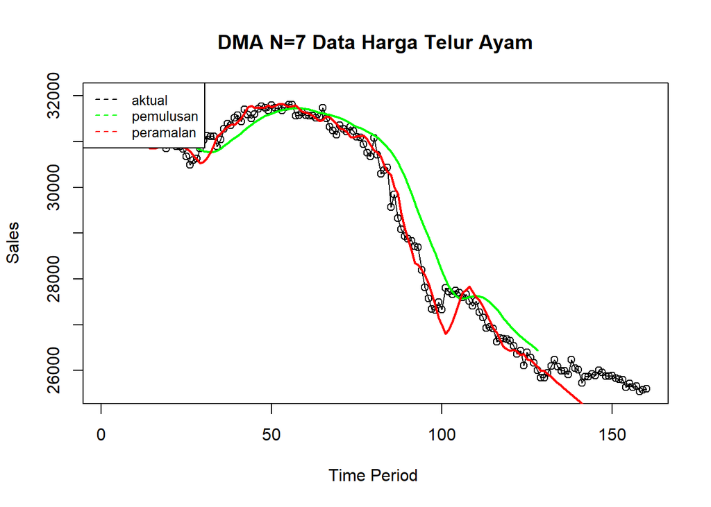

```r
ts.plot(telur.ts, xlab="Time Period ", ylab="Sales", main= "DMA N=7 Data Harga Telur Ayam")
points(telur.ts)
lines(data.gab2[,3],col="green",lwd=2)
lines(data.gab2[,6],col="red",lwd=2)
legend("topleft",c("aktual","pemulusan","peramalan"), lty=8, col=c("black","green","red"), cex=0.8)
```

Selanjutnya perhitungan akurasi dilakukan baik pada data latih maupun data uji. Perhitungan akurasi dilakukan dengan ukuran akurasi SSE, MSE dan MAPE.

```r
# Menghitung error data latih
error_train.dma <- train_ma.ts - ramalan_dma[1:length(train_ma.ts)]

SSE_train.dma <- sum(error_train.dma[8:length(train_ma.ts)]^2, na.rm = TRUE)
MSE_train.dma <- mean(error_train.dma[8:length(train_ma.ts)]^2, na.rm = TRUE)
MAPE_train.dma <- mean(abs(error_train.dma[8:length(train_ma.ts)] / train_ma.ts[8:length(train_ma.ts)]) * 100, na.rm = TRUE)

akurasi_train.dma <- matrix(c(SSE_train.dma, MSE_train.dma, MAPE_train.dma),
                            nrow = 3, ncol = 1)
row.names(akurasi_train.dma) <- c("SSE", "MSE", "MAPE")
colnames(akurasi_train.dma) <- c("Akurasi train m = 7")

akurasi_train.dma
```

```
##      Akurasi train m = 7
## SSE         7.007874e+06
## MSE         6.093803e+04
## MAPE        6.109365e-01
```

Perhitungan akurasi pada data latih menggunakan nilai MAPE menghasilkan nilai MAPE yang kurang dari 10% sehingga dikategorikan sangat baik. Selanjutnya, perhitungan nilai akurasi dilakukan pada data uji.

```r
n_train <- length(train_ma.ts)
n_test  <- length(test_ma.ts)
ramalan_test <- ramalan_dma[(n_train+1):(n_train+n_test)]
error_test.dma <- test_ma.ts - ramalan_test

SSE_test.dma <- sum(error_test.dma^2, na.rm = TRUE)
MSE_test.dma <- mean(error_test.dma^2, na.rm = TRUE)
MAPE_test.dma <- mean(abs(error_test.dma / test_ma.ts) * 100, na.rm = TRUE)

akurasi_test.dma <- matrix(c(SSE_test.dma, MSE_test.dma, MAPE_test.dma),nrow = 3, ncol = 1)
row.names(akurasi_test.dma) <- c("SSE", "MSE", "MAPE")
colnames(akurasi_test.dma) <- c("Akurasi test m = 7")

akurasi_test.dma
```

```
##      Akurasi test m = 7
## SSE        2.227607e+04
## MSE        2.227607e+04
## MAPE       5.775995e-01
```

Perhitungan akurasi menggunakan data latih menghasilkan nilai MAPE sebesar 0.61%, sedangkan pada data uji diperoleh nilai MAPE sebesar 0.58%. Kedua nilai ini berada jauh di bawah 10%, sehingga metode DMA dengan m=7 dapat dikategorikan memiliki tingkat akurasi sangat baik. Selain itu, hasil ini menunjukkan bahwa performa DMA (m=7) pada data uji sedikit lebih baik dibandingkan dengan pada data latih.

# Single Exponential Smoothing

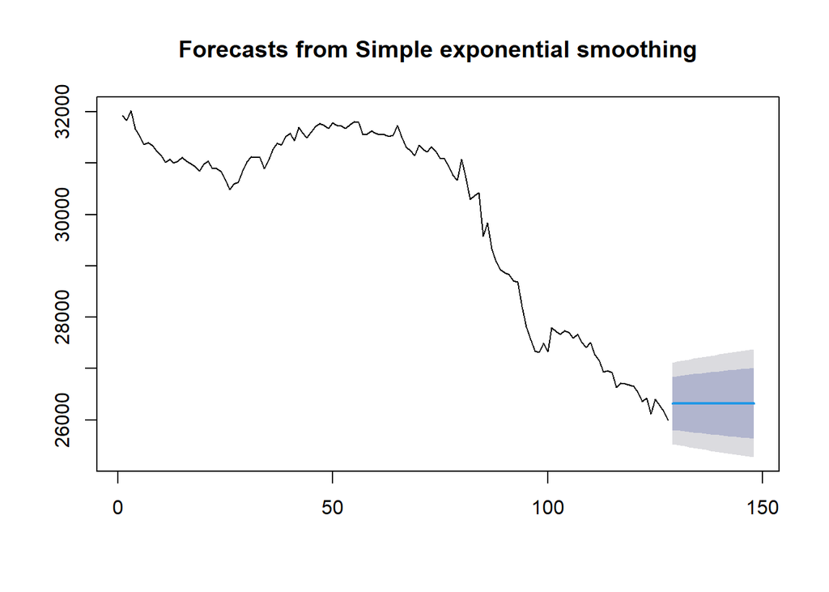

```r
ses.1 <- ses(train_ma.ts, h = 20, alpha = 0.2)
plot(ses.1)
```

```r
ses.1
```

```
##     Point Forecast    Lo 80    Hi 80    Lo 95    Hi 95
## 129       26322.69 25804.42 26840.96 25530.06 27115.32
## 130       26322.69 25794.16 26851.22 25514.37 27131.01
## 131       26322.69 25784.09 26861.29 25498.97 27146.41
## 132       26322.69 25774.20 26871.18 25483.85 27161.53
## 133       26322.69 25764.50 26880.88 25469.01 27176.38
## 134       26322.69 25754.95 26890.43 25454.41 27190.97
## 135       26322.69 25745.57 26899.81 25440.06 27205.32
## 136       26322.69 25736.33 26909.05 25425.94 27219.44
## 137       26322.69 25727.24 26918.14 25412.03 27233.35
## 138       26322.69 25718.29 26927.09 25398.34 27247.04
## 139       26322.69 25709.46 26935.92 25384.84 27260.54
## 140       26322.69 25700.77 26944.62 25371.54 27273.84
## 141       26322.69 25692.19 26953.19 25358.42 27286.96
## 142       26322.69 25683.72 26961.66 25345.48 27299.91
## 143       26322.69 25675.37 26970.01 25332.70 27312.68
## 144       26322.69 25667.12 26978.26 25320.09 27325.29
## 145       26322.69 25658.98 26986.40 25307.63 27337.75
## 146       26322.69 25650.94 26994.45 25295.33 27350.05
## 147       26322.69 25642.99 27002.40 25283.17 27362.21
## 148       26322.69 25635.13 27010.25 25271.15 27374.23
```

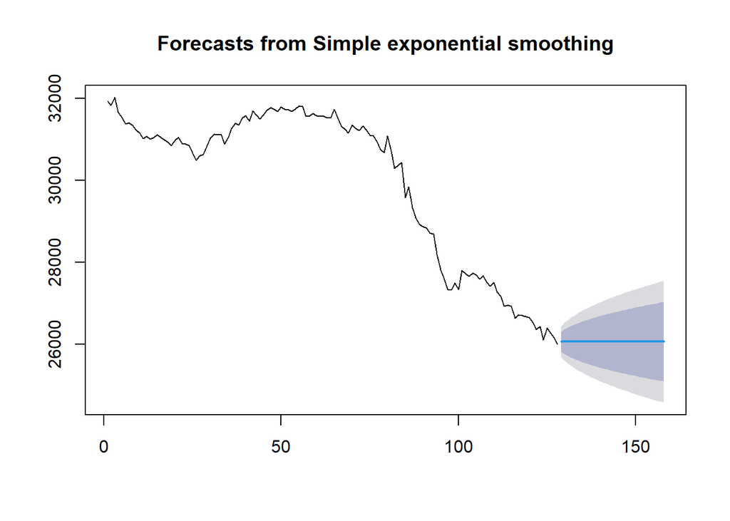

```r
ses.2 <- ses(train_ma.ts, h = 30, alpha = 0.7)
plot(ses.2)
```

```r
ses.2
```

```
##     Point Forecast    Lo 80    Hi 80    Lo 95    Hi 95
## 129       26060.46 25812.06 26308.86 25680.57 26440.36
## 130       26060.46 25757.25 26363.68 25596.74 26524.19
## 131       26060.46 25710.93 26410.00 25525.90 26595.03
## 132       26060.46 25670.07 26450.86 25463.41 26657.52
## 133       26060.46 25633.10 26487.83 25406.86 26714.06
## 134       26060.46 25599.08 26521.85 25354.84 26766.09
## 135       26060.46 25567.40 26553.53 25306.39 26814.54
## 136       26060.46 25537.64 26583.29 25260.87 26860.05
## 137       26060.46 25509.48 26611.44 25217.81 26903.12
## 138       26060.46 25482.70 26638.23 25176.84 26944.08
## 139       26060.46 25457.10 26663.83 25137.70 26983.23
## 140       26060.46 25432.54 26688.38 25100.14 27020.79
## 141       26060.46 25408.91 26712.01 25064.00 27056.92
## 142       26060.46 25386.11 26734.82 25029.13 27091.80
```

[output cut: 16 more lines]

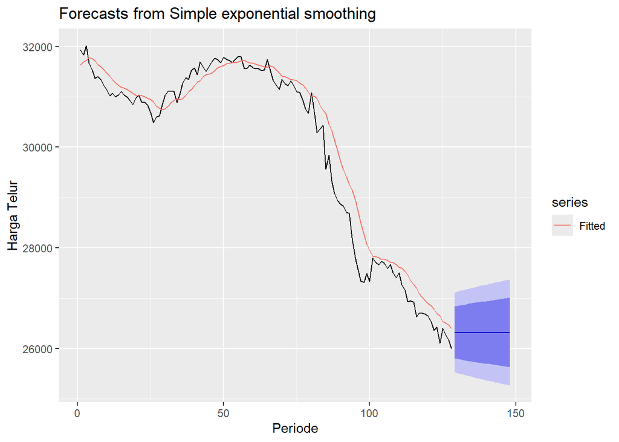

```r
autoplot(ses.1) +
  autolayer(fitted(ses.1), series="Fitted") +
  ylab("Harga Telur") + xlab("Periode")
```

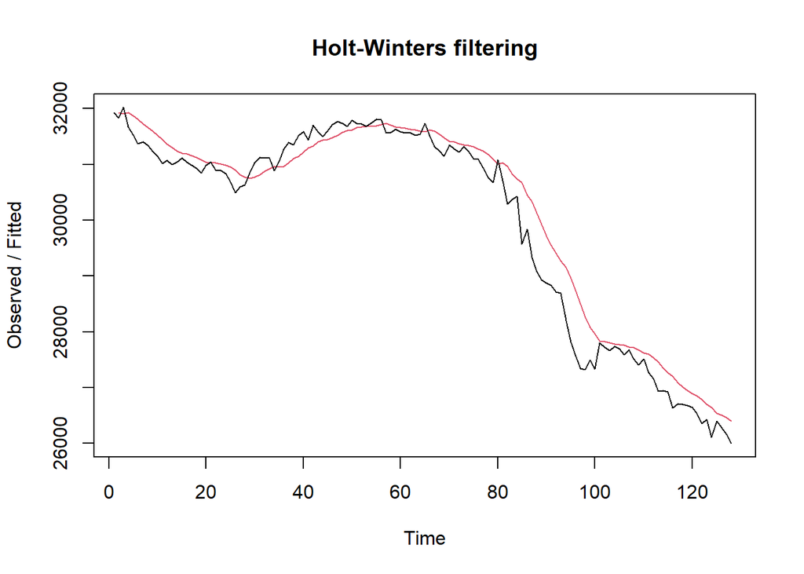

```r
ses1<- HoltWinters(train_ma.ts, gamma = FALSE, beta = FALSE, alpha = 0.2)
plot(ses1)
```

```r
ramalan1<- forecast(ses1, h=10)
ramalan1
```

```
##     Point Forecast    Lo 80    Hi 80    Lo 95    Hi 95
## 129       26322.69 25885.53 26759.85 25654.11 26991.27
## 130       26322.69 25876.87 26768.51 25640.87 27004.51
## 131       26322.69 25868.38 26777.00 25627.88 27017.50
## 132       26322.69 25860.04 26785.34 25615.13 27030.25
## 133       26322.69 25851.86 26793.53 25602.61 27042.77
## 134       26322.69 25843.81 26801.57 25590.30 27055.08
## 135       26322.69 25835.89 26809.49 25578.19 27067.19
## 136       26322.69 25828.10 26817.28 25566.28 27079.10
## 137       26322.69 25820.43 26824.95 25554.55 27090.83
## 138       26322.69 25812.88 26832.50 25543.00 27102.38
```

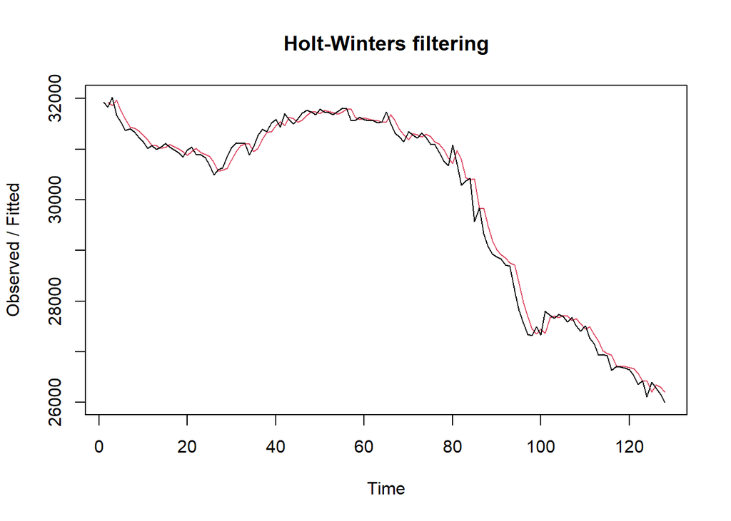

```r
ses2<- HoltWinters(train_ma.ts, gamma = FALSE, beta = FALSE, alpha = 0.7)
plot(ses2)
```

```r
ramalan2<- forecast(ses2, h=10)
ramalan2
```

```
##     Point Forecast    Lo 80    Hi 80    Lo 95    Hi 95
## 129       26060.46 25827.02 26293.91 25703.44 26417.48
## 130       26060.46 25775.51 26345.42 25624.67 26496.26
## 131       26060.46 25731.98 26388.95 25558.09 26562.83
## 132       26060.46 25693.58 26427.35 25499.36 26621.56
## 133       26060.46 25658.83 26462.09 25446.22 26674.70
## 134       26060.46 25626.86 26494.06 25397.33 26723.60
## 135       26060.46 25597.09 26523.83 25351.80 26769.13
## 136       26060.46 25569.12 26551.80 25309.03 26811.90
## 137       26060.46 25542.66 26578.26 25268.56 26852.37
## 138       26060.46 25517.49 26603.44 25230.06 26890.87
```

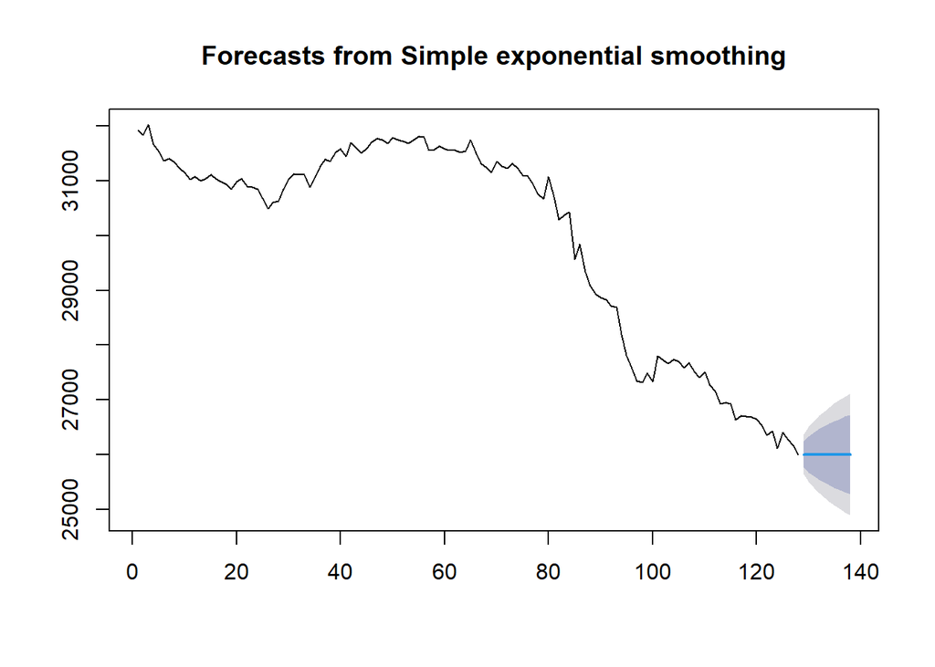

```r
ses.opt <- ses(train_ma.ts, h = 10, alpha = NULL)
plot(ses.opt)
```

```r
ses.opt
```

```
##     Point Forecast    Lo 80    Hi 80    Lo 95    Hi 95
## 129       26003.83 25769.49 26238.18 25645.43 26362.24
## 130       26003.83 25676.29 26331.37 25502.90 26504.76
## 131       26003.83 25604.27 26403.39 25392.76 26614.91
## 132       26003.83 25543.38 26464.28 25299.64 26708.03
## 133       26003.83 25489.66 26518.01 25217.47 26790.20
## 134       26003.83 25441.03 26566.63 25143.11 26864.56
## 135       26003.83 25396.29 26611.37 25074.68 26932.99
## 136       26003.83 25354.63 26653.04 25010.96 26996.71
## 137       26003.83 25315.48 26692.19 24951.08 27056.58
## 138       26003.83 25278.44 26729.23 24894.44 27113.23
```

```r
HWopt<- HoltWinters(train_ma.ts, gamma = FALSE, beta = FALSE,alpha = NULL)
HWopt
```

```
## Holt-Winters exponential smoothing without trend and without seasonal component.
##
## Call:
## HoltWinters(x = train_ma.ts, alpha = NULL, beta = FALSE, gamma = FALSE)
##
## Smoothing parameters:
##  alpha: 0.9764124
##  beta : FALSE
##  gamma: FALSE
##
## Coefficients:
##       [,1]
## a 26003.84
```

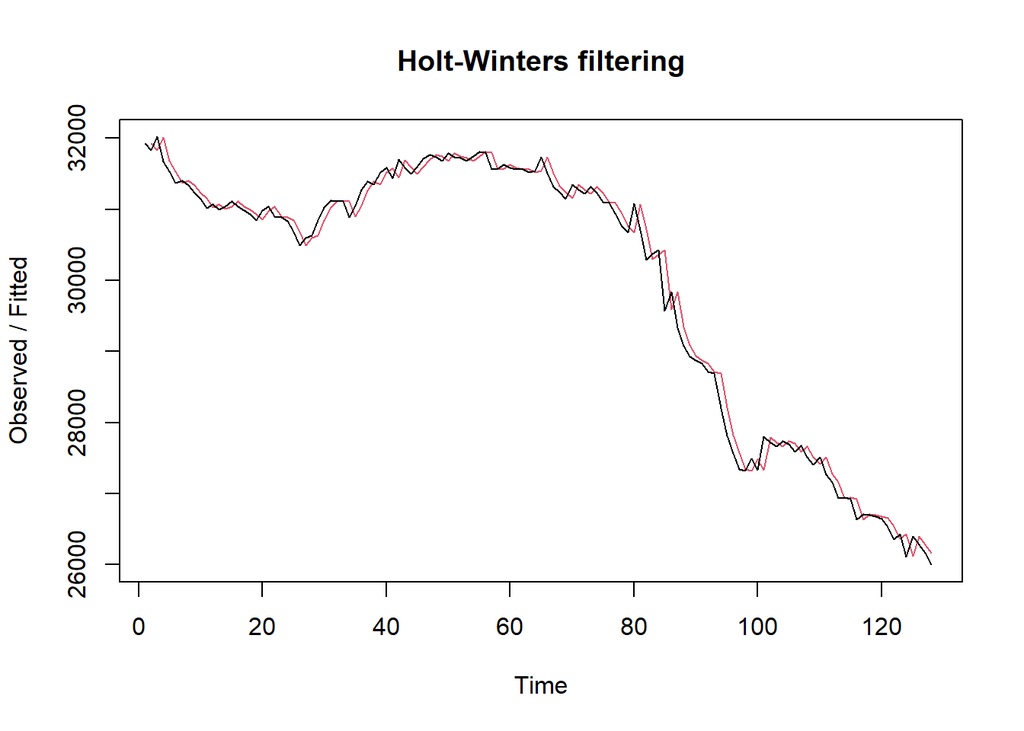

```r
plot(HWopt)
```

```r
ramalanopt<- forecast(HWopt, h=10)
ramalanopt
```

```
##     Point Forecast    Lo 80    Hi 80    Lo 95    Hi 95
## 129       26003.84 25777.71 26229.98 25658.00 26349.69
## 130       26003.84 25687.79 26319.90 25520.48 26487.21
## 131       26003.84 25618.30 26389.39 25414.20 26593.48
## 132       26003.84 25559.55 26448.14 25324.35 26683.33
## 133       26003.84 25507.70 26499.98 25245.06 26762.62
## 134       26003.84 25460.79 26546.90 25173.31 26834.37
## 135       26003.84 25417.62 26590.07 25107.29 26900.40
## 136       26003.84 25377.41 26630.27 25045.80 26961.88
## 137       26003.84 25339.64 26668.05 24988.03 27019.66
## 138       26003.84 25303.90 26703.79 24933.37 27074.31
```

## Akurasi Data Latih

```r
#Keakuratan Metode
#Pada data training

# SES dengan alpha = 0.2
SSE1<-ses1$SSE
MSE1<-ses1$SSE/length(train_ma.ts)
RMSE1<-sqrt(MSE1)

akurasi1 <- matrix(c(SSE1,MSE1,RMSE1))
row.names(akurasi1)<- c("SSE", "MSE", "RMSE")
colnames(akurasi1) <- c("Akurasi lamda=0.2")
akurasi1
```

```
##      Akurasi lamda=0.2
## SSE       2.085086e+07
## MSE       1.628973e+05
## RMSE      4.036054e+02
```

```r
SSE2<-ses2$SSE
MSE2<-ses2$SSE/length(train_ma.ts)
RMSE2<-sqrt(MSE2)

akurasi2 <- matrix(c(SSE2,MSE2,RMSE2))
row.names(akurasi2)<- c("SSE", "MSE", "RMSE")
colnames(akurasi2) <- c("Akurasi lamda=0.7")
akurasi2
```

```
##      Akurasi lamda=0.7
## SSE       4734395.2929
## MSE         36987.4632
## RMSE          192.3213
```

```r
SSE1<-ses1$SSE
SSE1
```

```
## [1] 20850856
```

```r
#Cara Manual
# Alpha = 0.2
fitted1<-ramalan1$fitted
sisaan1<-ramalan1$residuals
head(sisaan1)
```

```
## Time Series:
## Start = 1
## End = 6
## Frequency = 1
## [1]      NA -100.00  110.00 -262.00 -349.60 -439.68
```

```r
resid1<-train_ma.ts-ramalan1$fitted
head(resid1)
```

```
## Time Series:
## Start = 1
## End = 6
## Frequency = 1
## [1]      NA -100.00  110.00 -262.00 -349.60 -439.68
```

```r
SSE.1=sum(sisaan1[2:length(train_ma.ts)]^2)
SSE.1
```

```
## [1] 20850856
```

```r
MSE.1 = SSE.1/length(train_ma.ts)
MSE.1
```

```
## [1] 162897.3
```

```r
MAPE.1 = sum(abs(sisaan1[2:length(train_ma.ts)]/train_ma.ts[2:length(train_ma.ts)])*
               100)/length(train_ma.ts)
MAPE.1
```

```
## [1] 1.03866
```

```r
akurasi.1 <- matrix(c(SSE.1,MSE.1,MAPE.1))
row.names(akurasi.1)<- c("SSE", "MSE", "MAPE")
colnames(akurasi.1) <- c("Akurasi lamda=0.2")
akurasi.1
```

```
##      Akurasi lamda=0.2
## SSE       2.085086e+07
## MSE       1.628973e+05
## MAPE      1.038660e+00
```

```r
# Alpha = 0.7
fitted2<-ramalan2$fitted
sisaan2<-ramalan2$residuals
head(sisaan2)
```

```
## Time Series:
## Start = 1
## End = 6
## Frequency = 1
## [1]      NA -100.00  160.00 -302.00 -230.60 -229.18
```

```r
resid2<-train_ma.ts-ramalan2$fitted
head(resid2)
```

```
## Time Series:
## Start = 1
## End = 6
## Frequency = 1
## [1]      NA -100.00  160.00 -302.00 -230.60 -229.18
```

```r
SSE.2=sum(sisaan2[2:length(train_ma.ts)]^2)
SSE.2
```

```
## [1] 4734395
```

```r
MSE.2 = SSE.2/length(train_ma.ts)
MSE.2
```

```
## [1] 36987.46
```

```r
MAPE.2 = sum(abs(sisaan2[2:length(train_ma.ts)]/train_ma.ts[2:length(train_ma.ts)])*
               100)/length(train_ma.ts)
MAPE.2
```

```
## [1] 0.4721491
```

```r
akurasi.2 <- matrix(c(SSE.2,MSE.2,MAPE.2))
row.names(akurasi.2)<- c("SSE", "MSE", "MAPE")
colnames(akurasi.2) <- c("Akurasi lamda=0.7")
akurasi.2
```

```
##      Akurasi lamda=0.7
## SSE       4.734395e+06
## MSE       3.698746e+04
## MAPE      4.721491e-01
```

Berdasarkan nilai SSE, MSE, dan MAPE pada kedua parameter, nilai parameter λ = 0.7 menghasilkan akurasi yang lebih baik dibandingkan λ = 0.2. Hal ini ditunjukkan dengan nilai ukuran akurasi yang lebih kecil pada λ = 0.7. Berdasarkan nilai MAPE sebesar 0.47%, hasil peramalan ini dapat dikategorikan memiliki tingkat akurasi yang sangat baik.

## Akurasi Data Uji

```r
# jumlah observasi uji
n_test <- nrow(testing_ma)

# error (ramalan - aktual), samakan panjang dan tipe numeric
e1   <- as.numeric(ramalan1$mean)[1:n_test] - as.numeric(testing_ma$Jawa.Barat)
e2   <- as.numeric(ramalan2$mean)[1:n_test] - as.numeric(testing_ma$Jawa.Barat)
eopt <- as.numeric(ramalanopt$mean)[1:n_test] - as.numeric(testing_ma$Jawa.Barat)

# SSE / MSE / RMSE untuk masing-masing model (abaikan NA)
SSEtesting1  <- sum(e1^2,  na.rm = TRUE)
MSEtesting1  <- mean(e1^2, na.rm = TRUE)
RMSEtesting1 <- sqrt(MSEtesting1)

SSEtesting2  <- sum(e2^2,  na.rm = TRUE)
MSEtesting2  <- mean(e2^2, na.rm = TRUE)
RMSEtesting2 <- sqrt(MSEtesting2)

SSEtestingopt  <- sum(eopt^2,  na.rm = TRUE)
MSEtestingopt  <- mean(eopt^2, na.rm = TRUE)
RMSEtestingopt <- sqrt(MSEtestingopt)

# Tabel ringkas
akurasitesting_SSE <- matrix(c(SSEtesting1, SSEtesting2, SSEtestingopt),
                             nrow = 3,
                             dimnames = list(c("SSE1","SSE2","SSEopt"), "Nilai"))
akurasitesting_MSE <- matrix(c(MSEtesting1, MSEtesting2, MSEtestingopt),
                             nrow = 3,
                             dimnames = list(c("MSE1","MSE2","MSEopt"), "Nilai"))
akurasitesting_RMSE <- matrix(c(RMSEtesting1, RMSEtesting2, RMSEtestingopt),
                              nrow = 3,
                              dimnames = list(c("RMSE1","RMSE2","RMSEopt"), "Nilai"))

akurasitesting_SSE
```

```
##            Nilai
## SSE1   1117476.6
## SSE2    201900.6
## SSEopt  184741.3
```

```r
akurasitesting_MSE
```

```
##            Nilai
## MSE1   111747.66
## MSE2    20190.06
## MSEopt  18474.13
```

```r
akurasitesting_RMSE
```

```
##            Nilai
## RMSE1   334.2868
## RMSE2   142.0917
## RMSEopt 135.9196
```

```r
h_test <- length(test_ma.ts)

ramalan1 <- forecast(ses1, h = h_test)
ramalan2 <- forecast(ses2, h = h_test)
```

```r
# Akurasi out-of-sample (uji)
accuracy(ramalan1, test_ma.ts)
```

```
##                     ME     RMSE      MAE        MPE     MAPE     MASE      ACF1
## Training set -220.7602 405.1913 305.4081 -0.7778605 1.046839 2.299160 0.8556349
## Test set     -449.5655 481.5593 449.5655 -1.7421045 1.742105 3.384399 0.7469313
##              Theil's U
## Training set        NA
## Test set      4.230791
```

```r
accuracy(ramalan2, test_ma.ts)
```

```
##                      ME     RMSE      MAE        MPE      MAPE     MASE
## Training set  -66.02403 193.0769 140.4392 -0.2313120 0.4758668 1.057249
## Test set     -187.33835 254.7271 212.8475 -0.7285479 0.8258844 1.602349
##                   ACF1 Theil's U
## Training set 0.2462443        NA
## Test set     0.7469313  2.251899
```

```r
accuracy(ramalanopt, test_ma.ts)
```

```
##                     ME     RMSE      MAE         MPE      MAPE      MASE
## Training set -47.78991 182.1406 132.8261 -0.16752773 0.4496089 0.9999355
## Test set      13.15774 135.9196 113.7685  0.04787546 0.4367393 0.8564667
##                     ACF1 Theil's U
## Training set -0.07521384        NA
## Test set      0.27162997 0.9115681
```

# Double Exponential Smoothing (DES)

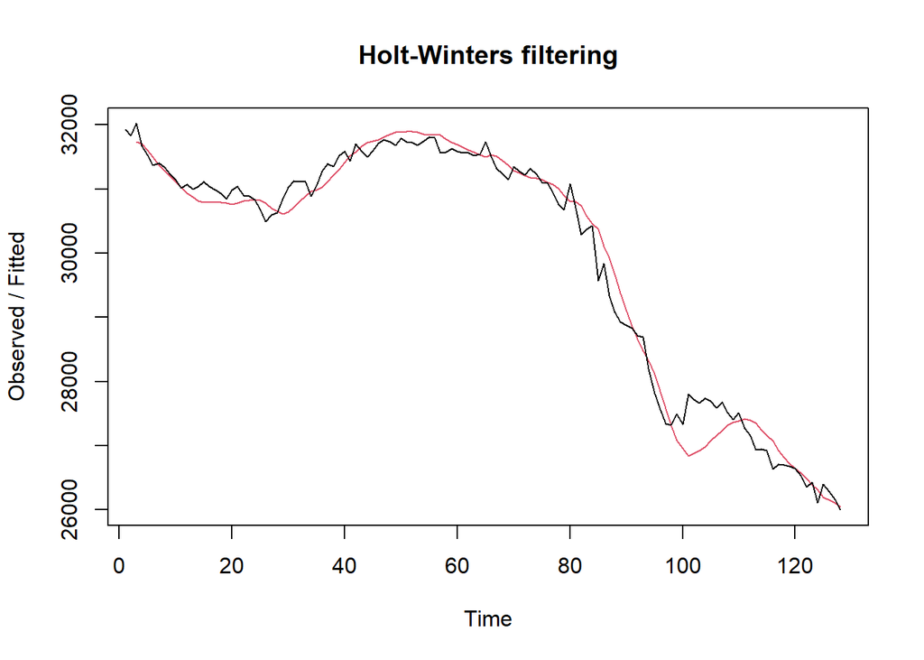

```r
#Lamda=0.2 dan gamma=0.2
des.1<- HoltWinters(train_ma.ts, gamma = FALSE, beta = 0.2, alpha = 0.2)
plot(des.1)
```

```r
#ramalan
ramalandes1<- forecast(des.1, h=10)
ramalandes1
```

```
##     Point Forecast    Lo 80    Hi 80    Lo 95    Hi 95
## 129       25967.57 25621.22 26313.93 25437.87 26497.28
## 130       25895.84 25539.66 26252.03 25351.10 26440.59
## 131       25824.12 25454.96 26193.27 25259.54 26388.69
## 132       25752.39 25366.95 26137.82 25162.92 26341.86
## 133       25680.66 25275.56 26085.76 25061.11 26300.21
## 134       25608.93 25180.79 26037.07 24954.15 26263.71
## 135       25537.20 25082.75 25991.65 24842.18 26232.22
## 136       25465.47 24981.57 25949.38 24725.40 26205.54
## 137       25393.74 24877.41 25910.08 24604.08 26183.41
## 138       25322.02 24770.45 25873.58 24478.47 26165.56
```

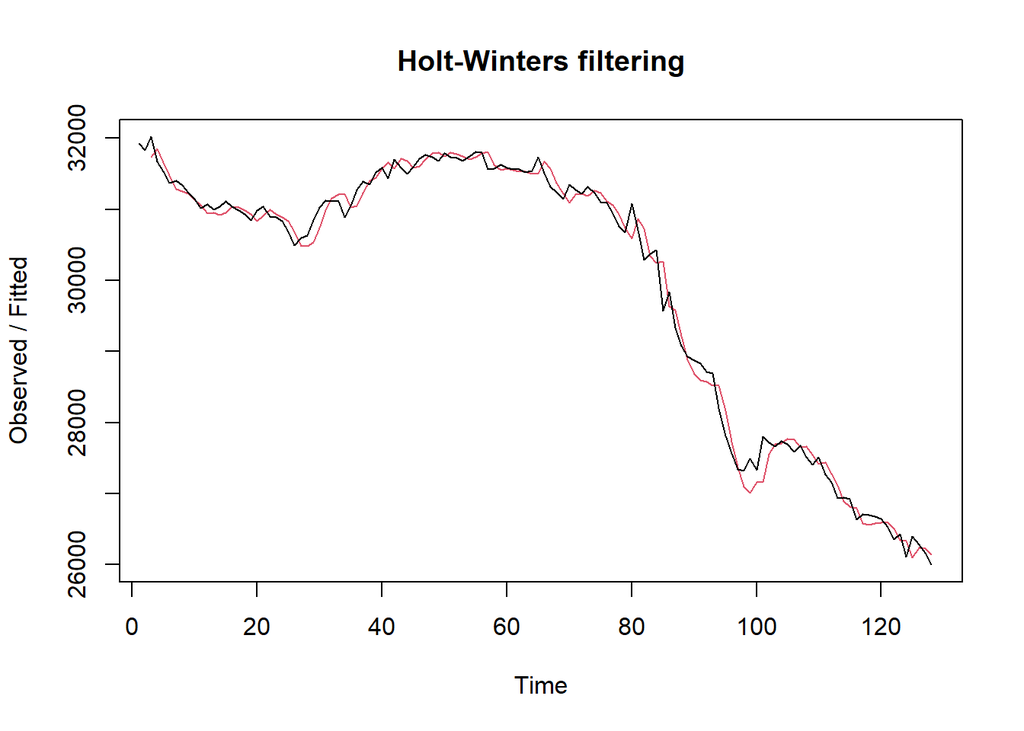

```r
#Lamda=0.6 dan gamma=0.3
des.2<- HoltWinters(train_ma.ts, gamma = FALSE, beta = 0.3, alpha = 0.6)
plot(des.2)
```

```r
#ramalan
ramalandes2<- forecast(des.2, h=10)
ramalandes2
```

```
##     Point Forecast    Lo 80    Hi 80    Lo 95    Hi 95
## 129       25980.79 25749.86 26211.73 25627.61 26333.98
## 130       25907.03 25614.15 26199.91 25459.11 26354.96
## 131       25833.27 25465.94 26200.60 25271.49 26395.05
## 132       25759.51 25307.58 26211.44 25068.35 26450.68
## 133       25685.75 25140.62 26230.88 24852.05 26519.45
## 134       25611.99 24966.11 26257.87 24624.20 26599.78
## 135       25538.23 24784.78 26291.68 24385.93 26690.53
## 136       25464.47 24597.18 26331.76 24138.06 26790.87
## 137       25390.70 24403.72 26377.69 23881.24 26900.17
## 138       25316.94 24204.75 26429.14 23615.99 27017.90
```

Selanjutnya jika ingin membandingkan plot data latih dan data uji adalah sebagai berikut.

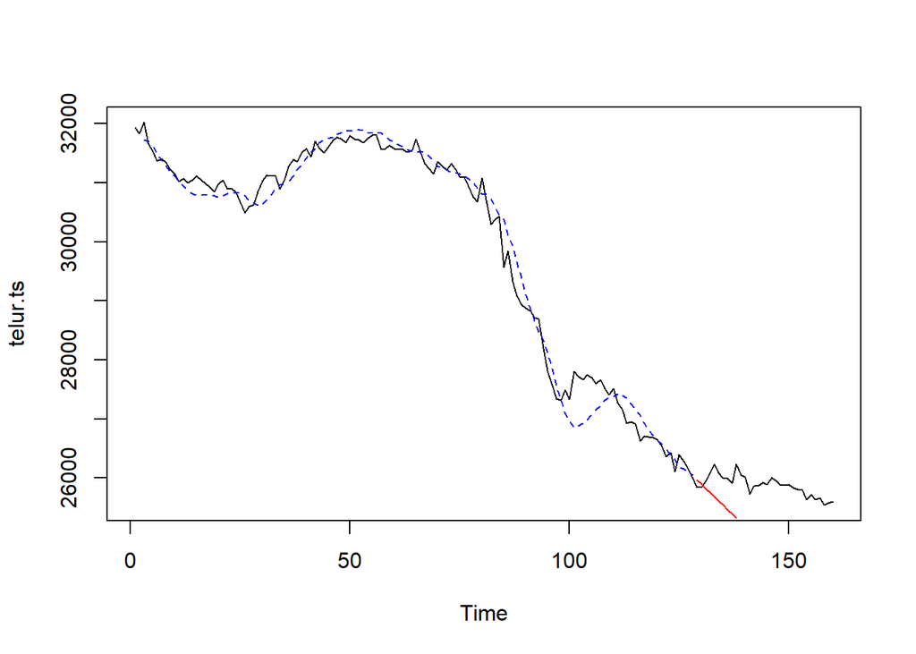

```r
plot(telur.ts)
lines(des.1$fitted[,1], lty=2, col="blue")
lines(ramalandes1$mean, col="red")
```

```r
#Lamda dan gamma optimum
des.opt<- HoltWinters(train_ma.ts, gamma = FALSE)
des.opt
```

```
## Holt-Winters exponential smoothing with trend and without seasonal component.
##
## Call:
## HoltWinters(x = train_ma.ts, gamma = FALSE)
##
## Smoothing parameters:
##  alpha: 0.7990758
##  beta : 0.1194491
##  gamma: FALSE
##
## Coefficients:
##          [,1]
## a 26022.66130
## b   -71.19901
```

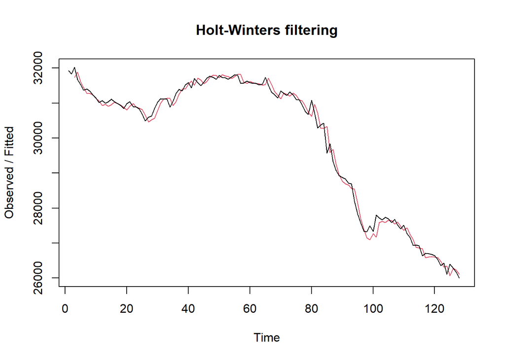

```r
plot(des.opt)
```

```r
#ramalan
ramalandesopt<- forecast(des.opt, h=10)
ramalandesopt
```

```
##     Point Forecast    Lo 80    Hi 80    Lo 95    Hi 95
## 129       25951.46 25728.06 26174.87 25609.80 26293.13
## 130       25880.26 25580.52 26180.01 25421.85 26338.68
## 131       25809.06 25436.56 26181.57 25239.37 26378.76
## 132       25737.87 25293.39 26182.34 25058.10 26417.63
## 133       25666.67 25149.80 26183.54 24876.18 26457.15
## 134       25595.47 25005.17 26185.77 24692.68 26498.26
## 135       25524.27 24859.16 26189.38 24507.07 26541.47
## 136       25453.07 24711.57 26194.56 24319.05 26587.09
## 137       25381.87 24562.30 26201.44 24128.45 26635.29
## 138       25310.67 24411.28 26210.06 23935.17 26686.17
```

Selanjutnya akan dilakukan perhitungan akurasi pada data latih maupun data uji dengan ukuran akurasi SSE, MSE dan MAPE.

## Akurasi Data Latih

```r
#Akurasi Data Training
ssedes.train1<-des.1$SSE
msedes.train1<-ssedes.train1/length(train_ma.ts)
sisaandes1<-ramalandes1$residuals
head(sisaandes1)
```

```
## Time Series:
## Start = 1
## End = 6
## Frequency = 1
## [1]       NA       NA  290.000  -29.600  -74.096 -126.729
```

```r
mapedes.train1 <- sum(abs(sisaandes1[3:length(train_ma.ts)]/train_ma.ts[3:length(train_ma.ts)])
                      *100)/length(train_ma.ts)

akurasides.1 <- matrix(c(ssedes.train1,msedes.train1,mapedes.train1))
row.names(akurasides.1)<- c("SSE", "MSE", "MAPE")
colnames(akurasides.1) <- c("Akurasi lamda=0.2 dan gamma=0.2")
akurasides.1
```

```
##      Akurasi lamda=0.2 dan gamma=0.2
## SSE                     9.134102e+06
## MSE                     7.136017e+04
## MAPE                    6.630825e-01
```

```r
ssedes.train2<-des.2$SSE
msedes.train2<-ssedes.train2/length(train_ma.ts)
sisaandes2<-ramalandes2$residuals
head(sisaandes2)
```

```
## Time Series:
## Start = 1
## End = 6
## Frequency = 1
## [1]        NA        NA  290.0000 -186.2000 -133.1640 -107.9801
```

```r
mapedes.train2 <- sum(abs(sisaandes2[3:length(train_ma.ts)]/train_ma.ts[3:length(train_ma.ts)])
                      *100)/length(train_ma.ts)

akurasides.2 <- matrix(c(ssedes.train2,msedes.train2,mapedes.train2))
row.names(akurasides.2)<- c("SSE", "MSE", "MAPE")
colnames(akurasides.2) <- c("Akurasi lamda=0.6 dan gamma=0.3")
akurasides.2
```

```
##      Akurasi lamda=0.6 dan gamma=0.3
## SSE                     4.059220e+06
## MSE                     3.171265e+04
## MAPE                    4.513410e-01
```

Hasil akurasi dari data latih didapatkan skenario 2 dengan lamda=0.6 dan gamma=0.3 memiliki hasil yang lebih baik. Namun untuk kedua skenario dapat dikategorikan peramalan sangat baik berdasarkan nilai MAPE-nya.

## Akurasi Data Uji

```r
#Akurasi Data Testing
selisihdes1<-ramalandes1$mean-test_ma.ts
selisihdes1
```

```
## Time Series:
## Start = 129
## End = 138
## Frequency = 1
##  [1]  127.57374   55.84499 -125.88375 -347.61249 -549.34123 -481.06997
##  [7] -452.79872 -524.52746 -516.25620 -907.98494
```

```r
SSEtestingdes1<-sum(selisihdes1^2)
MSEtestingdes1<-SSEtestingdes1/length(test_ma.ts)
MAPEtestingdes1<-sum(abs(selisihdes1/test_ma.ts)*100)/length(test_ma.ts)

selisihdes2<-ramalandes2$mean-test_ma.ts
selisihdes2
```

```
## Time Series:
## Start = 129
## End = 138
## Frequency = 1
##  [1]  140.79451   67.03319 -116.72812 -340.48944 -544.25076 -478.01208
##  [7] -451.77340 -525.53472 -519.29603 -913.05735
```

```r
SSEtestingdes2<-sum(selisihdes2^2)
MSEtestingdes2<-SSEtestingdes2/length(test_ma.ts)
MAPEtestingdes2<-sum(abs(selisihdes2/test_ma.ts)*100)/length(test_ma.ts)

selisihdesopt<-ramalandesopt$mean-test_ma.ts
selisihdesopt
```

```
## Time Series:
## Start = 129
## End = 138
## Frequency = 1
##  [1]  111.46229   40.26327 -140.93574 -362.13476 -563.33377 -494.53278
##  [7] -465.73180 -536.93081 -528.12983 -919.32884
```

```r
SSEtestingdesopt<-sum(selisihdesopt^2)
MSEtestingdesopt<-SSEtestingdesopt/length(test_ma.ts)
MAPEtestingdesopt<-sum(abs(selisihdesopt/test_ma.ts)*100)/length(test_ma.ts)

akurasitestingdes <-
  matrix(c(SSEtestingdes1,MSEtestingdes1,MAPEtestingdes1,SSEtestingdes2,MSEtestingdes2,
           MAPEtestingdes2,SSEtestingdesopt,MSEtestingdesopt,MAPEtestingdesopt),
         nrow=3,ncol=3)
row.names(akurasitestingdes)<- c("SSE", "MSE", "MAPE")
colnames(akurasitestingdes) <- c("des ske1","des ske2","des opt")
akurasitestingdes
```

```
##          des ske1     des ske2      des opt
## SSE  2.260392e+06 2.262208e+06 2.356244e+06
## MSE  7.063724e+04 7.069399e+04 7.363264e+04
## MAPE 4.899845e-01 4.909771e-01 4.988126e-01
```

# Perbandingan SES dan DES

```r
MSEfull <-
  matrix(c(MSEtesting1,MSEtesting2,MSEtestingopt,MSEtestingdes1,MSEtestingdes2,
           MSEtestingdesopt),nrow=3,ncol=2)
row.names(MSEfull)<- c("ske 1", "ske 2", "ske opt")
colnames(MSEfull) <- c("ses","des")
MSEfull
```

```
##               ses      des
## ske 1   111747.66 70637.24
## ske 2    20190.06 70693.99
## ske opt  18474.13 73632.64
```

Kedua metode dapat dibandingkan menggunakan ukuran akurasi yang sama, yaitu MSE. Pada skenario 1, metode DES lebih baik dibandingkan SES karena memiliki nilai MSE yang lebih kecil. Namun, pada skenario 2 dan skenario optimal, metode SES lebih unggul dibandingkan DES, ditunjukkan dengan nilai MSE yang lebih kecil (20,190.06 vs 70,693.99 pada skenario 2, dan 18,474.13 vs 73,632.64 pada skenario optimal). Dengan demikian, secara keseluruhan metode SES dapat dikatakan memberikan hasil yang lebih baik pada data ini.